# Regional Disparities in Cardiovascular & Cerebrovascular Mortality across New York State

Eliana Almazan

April 20, 2023

# 1 Executive Summary

**Key Findings:**

- **MANOVA** revealed highly significant differences in mortality rates across NY regions (Pillai’s trace p = 8.52 × 10⁻⁹), rejecting the null hypothesis of equal means.
- **Post-hoc Tukey tests** identified Western New York and Hudson Valley as the most significantly different pair for cardiovascular mortality (p = 0.030), and New York City vs. Finger Lakes, Northeastern NY, and Western NY as the most divergent for cerebrovascular mortality (p ≈ 0.0000001).
- **Multilinear regression** found that region significantly predicted cerebrovascular mortality (R² = 0.671, p = 1.7 × 10⁻⁹), but not cardiovascular mortality (R² = 0.330, p = 0.014 at α = 0.01).

# 2 Introduction

Cardiovascular disease is the leading cause of death in the United States. Every year approximately 697,000 people die of heart disease (Centers for Disease Control and Prevention, 2022). Cardiovascular disease encompasses numerous conditions such as heart failure, coronary heart disease, or any other condition affecting the heart and blood vessels. Cerebrovascular disease, or stroke, occurs when the blood supply to the brain is interrupted.

Both of these diseases disproportionately affect low- and middle-income populations (Kelli et al., 2018). Key social determinants associated with both conditions include income level, education, employment status, and broader socioeconomic factors. The relationship between diet, exercise, and cardiovascular and cerebrovascular disease is crucial in maintaining a healthy cardiovascular system and reducing the risk of these conditions.

# 3 Dataset

For this project, the dataset *“Community Health Obesity and Diabetes Related Indicators: 2008–2012”* (Health.data.ny.gov, 2021) was used. It comprises 63 New York counties and their regional classifications, along with numerous health indicators including:

- Diabetes and obesity hospitalizations for adults and children
- Cirrhosis mortality rates
- Diet and exercise habits
- Cardiovascular and cerebrovascular mortality rates

The primary research questions were:

1. Are there significant differences in the means of cardiovascular and cerebrovascular mortality rates per 100,000 people across the nine regions of New York?
2. Is there a **linear** relationship between these mortality rates and diet (age-adjusted percentage of adults eating 5 or more fruits or vegetables per day), lack of exercise (age-adjusted percentage of adults who did not participate in leisure-time physical activity in the last 30 days), and region?

# 4 Analysis 1: MANOVA and Factorial ANOVA

## 4.1 Hypotheses

A factorial MANOVA was conducted using cardiovascular and cerebrovascular mortality rates as dependent variables and NY regions as the independent variable.

| Hypothesis | Statement |
| --- | --- |
| **H₀ (main effect)** | The means of cardiovascular and cerebrovascular mortality rates are equal across all regions. |
| **H₁ (main effect)** | At least one region has a different mean for cardiovascular or cerebrovascular mortality. |
| **H₀ (interaction)** | There are no interaction effects between cardiovascular and cerebrovascular mortality rates across regions. |
| **H₁ (interaction)** | There are significant interaction effects across regions. |

The F-test was used at α = 0.05. If p < 0.05, we reject H₀.

## 4.2 MANOVA Results

```r
ny_fit <- manova(
  cbind(Cardiovascular.Mortality, Cerebrovascular.Mortality) ~ `Region Name`,
  data = ny_data
)

summary(ny_fit)
```

```
##               Df  Pillai approx F num Df den Df    Pr(>F)
## `Region Name`  8 0.91817   5.7289     16    108 8.522e-09 ***
## Residuals     54
## ---
## Signif. codes:  0 '***' 0.001 '**' 0.01 '*' 0.05 '.' 0.1 ' ' 1
```

```r
summary.aov(ny_fit)
```

```
##  Response Cardiovascular.Mortality :
##               Df Sum Sq Mean Sq F value  Pr(>F)
## `Region Name`  8  74168  9271.0  2.7946 0.01153 *
## Residuals     54 179147  3317.5
## ---
## Signif. codes:  0 '***' 0.001 '**' 0.01 '*' 0.05 '.' 0.1 ' ' 1
##
##  Response Cerebrovascular.Mortality :
##               Df Sum Sq Mean Sq F value    Pr(>F)
## `Region Name`  8 4689.8  586.22  12.843 3.867e-10 ***
## Residuals     54 2464.9   45.65
## ---
## Signif. codes:  0 '***' 0.001 '**' 0.01 '*' 0.05 '.' 0.1 ' ' 1
```

> **Interpretation:** The overall MANOVA was highly significant (p = 8.52 × 10⁻⁹), rejecting the null hypothesis. Individual ANOVAs confirmed significant regional differences in both cardiovascular mortality (p = 0.0115) and cerebrovascular mortality (p = 3.87 × 10⁻¹⁰).

## 4.3 Effect Size (η²)

Effect size helps quantify *how much* of the variance in mortality rates is explained by region — not just whether the difference is statistically significant.

```r
# Eta-squared (η²) for each response variable
# η² = SS_effect / SS_total
ss_cardio_region   <- 74168
ss_cardio_residual <- 179147
eta2_cardio <- ss_cardio_region / (ss_cardio_region + ss_cardio_residual)

ss_cerebro_region   <- 4689.8
ss_cerebro_residual <- 2464.9
eta2_cerebro <- ss_cerebro_region / (ss_cerebro_region + ss_cerebro_residual)

data.frame(
  Outcome     = c("Cardiovascular Mortality", "Cerebrovascular Mortality"),
  Eta_Squared = round(c(eta2_cardio, eta2_cerebro), 3),
  Interpretation = c(
    ifelse(eta2_cardio  > 0.14, "Large effect", ifelse(eta2_cardio  > 0.06, "Medium effect", "Small effect")),
    ifelse(eta2_cerebro > 0.14, "Large effect", ifelse(eta2_cerebro > 0.06, "Medium effect", "Small effect"))
  )
)
```

| Outcome | Eta_Squared | Interpretation |
| --- | --- | --- |
| Cardiovascular Mortality | 0.293 | Large effect |
| Cerebrovascular Mortality | 0.655 | Large effect |

> Region explains **29.3%** of variance in cardiovascular mortality and **65.5%** of variance in cerebrovascular mortality — a large effect for cerebrovascular disease.

# 5 Analysis 2: Post-Hoc Tukey Tests

## 5.1 Cardiovascular Mortality

```r
ny_fit1Tukey <- aov(
  Cardiovascular.Mortality ~ factor(`Region Name`),
  data = ny_data
)
summary(ny_fit1Tukey)
```

```
##                       Df Sum Sq Mean Sq F value Pr(>F)
## factor(`Region Name`)  8  74168    9271   2.795 0.0115 *
## Residuals             54 179147    3318
## ---
## Signif. codes:  0 '***' 0.001 '**' 0.01 '*' 0.05 '.' 0.1 ' ' 1
```

```r
TukeyHSD(ny_fit1Tukey)
```

```
##   Tukey multiple comparisons of means
##     95% family-wise confidence level
##
## Fit: aov(formula = Cardiovascular.Mortality ~ factor(`Region Name`), data = ny_data)
##
## $`factor(`Region Name`)`
##                                              diff         lwr       upr
## Finger Lakes-Central New York            3.836364  -79.802605  87.47533
## Hudson Valley-Central New York         -32.135065 -122.105985  57.83585
## Nassau-Suffolk-Central New York         18.336364 -124.708282 161.38101
## New York-Penn-Central New York          71.103030  -50.101351 192.30741
## New York City-Central New York         -26.783636 -127.150399  73.58313
## New York State-Central New York         -8.263636 -202.623036 186.09576
## Northeastern New York-Central New York  43.012834  -28.993298 115.01897
## Western New York-Central New York       69.811364  -16.654908 156.27764
## Hudson Valley-Finger Lakes             -35.971429 -129.749433  57.80658
## Nassau-Suffolk-Finger Lakes             14.500000 -130.969304 159.96930
## New York-Penn-Finger Lakes              67.266667  -56.789972 191.32331
## New York City-Finger Lakes             -30.620000 -134.413231  73.17323
## New York State-Finger Lakes            -12.100000 -208.250769 184.05077
## Northeastern New York-Finger Lakes      39.176471  -37.533573 115.88651
## Western New York-Finger Lakes           65.975000  -24.446037 156.39604
## Nassau-Suffolk-Hudson Valley            50.471429  -98.728463 199.67132
## New York-Penn-Hudson Valley            103.238095  -25.172726 231.64892
## New York City-Hudson Valley              5.351429 -103.608766 114.31162
## New York State-Hudson Valley            23.871429 -175.061760 222.80462
## Northeastern New York-Hudson Valley     75.147899   -8.420755 158.71655
## Western New York-Hudson Valley         101.946429    5.638313 198.25454
## New York-Penn-Nassau-Suffolk            52.766667 -117.104882 222.63822
## New York City-Nassau-Suffolk           -45.120000 -200.809846 110.56985
## New York State-Nassau-Suffolk          -26.600000 -254.506598 201.30660
## Northeastern New York-Nassau-Suffolk    24.676471 -114.430410 163.78335
## Western New York-Nassau-Suffolk         51.475000  -95.638077 198.58808
## New York City-New York-Penn            -97.886667 -233.783906  38.01057
## New York State-New York-Penn           -79.366667 -294.239068 135.50573
## Northeastern New York-New York-Penn    -28.090196 -144.621117  88.44073
## Western New York-New York-Penn          -1.291667 -127.271779 124.68845
## New York State-New York City            18.520000 -185.325859 222.36586
## Northeastern New York-New York City     69.796471  -24.873697 164.46664
## Western New York-New York City          96.595000   -9.489748 202.67975
```

[output cut: 25 more lines]

```
## New York-Penn-Nassau-Suffolk           0.9839598
## New York City-Nassau-Suffolk           0.9897149
## New York State-Nassau-Suffolk          0.9999863
## Northeastern New York-Nassau-Suffolk   0.9996720
## Western New York-Nassau-Suffolk        0.9667971
## New York City-New York-Penn            0.3448155
## New York State-New York-Penn           0.9545372
## Northeastern New York-New York-Penn    0.9970230
## Western New York-New York-Penn         1.0000000
## New York State-New York City           0.9999981
## Northeastern New York-New York City    0.3146074
## Western New York-New York City         0.1013307
## Northeastern New York-New York State   0.9938975
## Western New York-New York State        0.9334433
## Western New York-Northeastern New York 0.9739940
```

> **Most significant pair:** Western New York vs. Hudson Valley (p = 0.030). No other pairs reached significance at α = 0.05 for cardiovascular mortality.

## 5.2 Cerebrovascular Mortality

```r
ny_fit2Tukey <- aov(
  Cerebrovascular.Mortality ~ factor(`Region Name`),
  data = ny_data
)
summary(ny_fit2Tukey)
```

```
##                       Df Sum Sq Mean Sq F value   Pr(>F)
## factor(`Region Name`)  8   4690   586.2   12.84 3.87e-10 ***
## Residuals             54   2465    45.6
## ---
## Signif. codes:  0 '***' 0.001 '**' 0.01 '*' 0.05 '.' 0.1 ' ' 1
```

```r
TukeyHSD(ny_fit2Tukey)
```

```
##   Tukey multiple comparisons of means
##     95% family-wise confidence level
##
## Fit: aov(formula = Cerebrovascular.Mortality ~ factor(`Region Name`), data = ny_data)
##
## $`factor(`Region Name`)`
##                                               diff           lwr          upr
## Finger Lakes-Central New York            0.6424242  -9.168298934  10.45314742
## Hudson Valley-Central New York         -15.9194805 -26.472931836  -5.36602920
## Nassau-Suffolk-Central New York        -16.3409091 -33.119827293   0.43800911
## New York-Penn-Central New York           2.9090909 -11.307997661  17.12617948
## New York City-Central New York         -26.7709091 -38.543776902 -14.99804128
## New York State-Central New York        -15.0909091 -37.888969576   7.70715139
## Northeastern New York-Central New York  -2.6026738 -11.048882986   5.84353539
## Western New York-Central New York        0.9090909  -9.233270583  11.05145240
## Hudson Valley-Finger Lakes             -16.5619048 -27.561921290  -5.56188823
## Nassau-Suffolk-Finger Lakes            -16.9833333 -34.046660235   0.07999357
## New York-Penn-Finger Lakes               2.2666667 -12.284987409  16.81832074
## New York City-Finger Lakes             -27.4133333 -39.588120618 -15.23854605
## New York State-Finger Lakes            -15.7333333 -38.741518634   7.27485197
## Northeastern New York-Finger Lakes      -3.2450980 -12.243068844   5.75287277
## Western New York-Finger Lakes            0.2666667 -10.339582696  10.87291603
## Nassau-Suffolk-Hudson Valley            -0.4214286 -17.922347702  17.07949056
## New York-Penn-Hudson Valley             18.8285714   3.766178465  33.89096439
## New York City-Hudson Valley            -10.8514286 -23.632292818   1.92943567
## New York State-Hudson Valley             0.8285714 -22.505987412  24.16313027
## Northeastern New York-Hudson Valley     13.3168067   3.514331319  23.11928213
## Western New York-Hudson Valley          16.8285714   5.531776706  28.12536615
## New York-Penn-Nassau-Suffolk            19.2500000  -0.675672965  39.17567297
## New York City-Nassau-Suffolk           -10.4300000 -28.692180927   7.83218093
## New York State-Nassau-Suffolk            1.2500000 -25.483095549  27.98309555
## Northeastern New York-Nassau-Suffolk    13.7382353  -2.578789109  30.05525970
## Western New York-Nassau-Suffolk         17.2500000  -0.006138975  34.50613898
## New York City-New York-Penn            -29.6800000 -45.620538372 -13.73946163
## New York State-New York-Penn           -18.0000000 -43.204204193   7.20420419
## Northeastern New York-New York-Penn     -5.5117647 -19.180663592   8.15713418
## Western New York-New York-Penn          -2.0000000 -16.777274570  12.77727457
## New York State-New York City            11.6800000 -12.230807558  35.59080756
## Northeastern New York-New York City     24.1682353  13.063569344  35.27290124
## Western New York-New York City          27.6800000  15.236421222  40.12357878
```

[output cut: 25 more lines]

```
## New York-Penn-Nassau-Suffolk           0.0659141
## New York City-Nassau-Suffolk           0.6527334
## New York State-Nassau-Suffolk          1.0000000
## Northeastern New York-Nassau-Suffolk   0.1651907
## Western New York-Nassau-Suffolk        0.0501477
## New York City-New York-Penn            0.0000055
## New York State-New York-Penn           0.3561110
## Northeastern New York-New York-Penn    0.9262125
## Western New York-New York-Penn         0.9999573
## New York State-New York City           0.8121237
## Northeastern New York-New York City    0.0000001
## Western New York-New York City         0.0000001
## Northeastern New York-New York State   0.6842352
## Western New York-New York State        0.4002308
## Western New York-Northeastern New York 0.9502758
```

> **Most significant pairs:** New York City vs. Finger Lakes, Northeastern NY, and Western NY (all p ≈ 0.0000001), indicating that NYC has dramatically lower cerebrovascular mortality than upstate regions.

# 6 Visualizations

## 6.1 Box Plots by Region

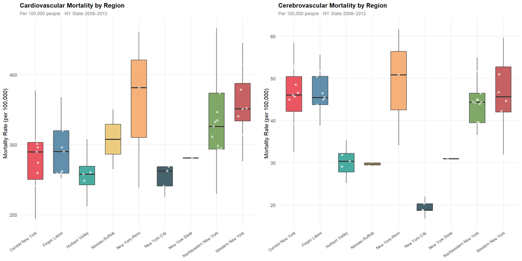

```r
# Custom color palette
region_colors <- c(
  "#E63946", "#457B9D", "#2A9D8F", "#E9C46A", "#F4A261",
  "#264653", "#A8DADC", "#6A994E", "#BC4749"
)

p1 <- ggplot(
  ny_data,
  aes(x = `Region Name`, y = Cardiovascular.Mortality, fill = `Region Name`)
) +
  geom_boxplot(outlier.shape = NA, alpha = 0.85, width = 0.6) +
  geom_jitter(width = 0.18, size = 1.8, alpha = 0.55, color = "white") +
  scale_fill_manual(values = region_colors) +
  labs(
    title    = "Cardiovascular Mortality by Region",
    subtitle = "Per 100,000 people · NY State 2008–2012",
    x        = NULL,
    y        = "Mortality Rate (per 100,000)"
  ) +
  theme_minimal(base_size = 11) +
  theme(
    legend.position  = "none",
    axis.text.x      = element_text(angle = 35, hjust = 1, size = 8),
    plot.title       = element_text(face = "bold", size = 12),
    plot.subtitle    = element_text(color = "gray50", size = 9),
    panel.grid.minor = element_blank()
  )

p2 <- ggplot(
  ny_data,
  aes(x = `Region Name`, y = Cerebrovascular.Mortality, fill = `Region Name`)
) +
  geom_boxplot(outlier.shape = NA, alpha = 0.85, width = 0.6) +
  geom_jitter(width = 0.18, size = 1.8, alpha = 0.55, color = "white") +
  scale_fill_manual(values = region_colors) +
  labs(
    title    = "Cerebrovascular Mortality by Region",
    subtitle = "Per 100,000 people · NY State 2008–2012",
    x        = NULL,
    y        = "Mortality Rate (per 100,000)"
  ) +
  theme_minimal(base_size = 11) +
  theme(
    legend.position  = "none",
    axis.text.x      = element_text(angle = 35, hjust = 1, size = 8),
    plot.title       = element_text(face = "bold", size = 12),
    plot.subtitle    = element_text(color = "gray50", size = 9),
    panel.grid.minor = element_blank()
  )

grid.arrange(p1, p2, ncol = 2)
```

## 6.2 Regional Means Comparison

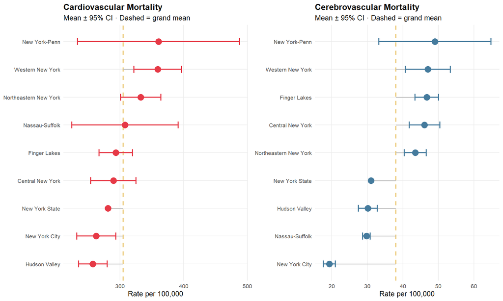

```r
# Compute means and CIs per region
region_summary <- ny_data %>%
  group_by(`Region Name`) %>%
  summarise(
    cardio_mean  = mean(Cardiovascular.Mortality,  na.rm = TRUE),
    cardio_se    = sd(Cardiovascular.Mortality,    na.rm = TRUE) / sqrt(n()),
    cerebro_mean = mean(Cerebrovascular.Mortality, na.rm = TRUE),
    cerebro_se   = sd(Cerebrovascular.Mortality,   na.rm = TRUE) / sqrt(n()),
    .groups = "drop"
  )

# Cardiovascular means
pc <- ggplot(region_summary, aes(x = reorder(`Region Name`, cardio_mean), y = cardio_mean)) +
  geom_hline(yintercept = mean(region_summary$cardio_mean), linetype = "dashed",
             color = "#E9C46A", linewidth = 0.8) +
  geom_segment(aes(xend = reorder(`Region Name`, cardio_mean), y = mean(region_summary$cardio_mean),
                   yend = cardio_mean), color = "gray75", linewidth = 0.7) +
  geom_errorbar(aes(ymin = cardio_mean - 1.96 * cardio_se,
                    ymax = cardio_mean + 1.96 * cardio_se),
                width = 0.25, color = "#E63946", linewidth = 0.8) +
  geom_point(size = 4, color = "#E63946") +
  coord_flip() +
  labs(title = "Cardiovascular Mortality",
       subtitle = "Mean ± 95% CI · Dashed = grand mean",
       x = NULL, y = "Rate per 100,000") +
  theme_minimal(base_size = 10) +
  theme(plot.title = element_text(face = "bold"), panel.grid.minor = element_blank())

# Cerebrovascular means
pb <- ggplot(region_summary, aes(x = reorder(`Region Name`, cerebro_mean), y = cerebro_mean)) +
  geom_hline(yintercept = mean(region_summary$cerebro_mean), linetype = "dashed",
             color = "#E9C46A", linewidth = 0.8) +
  geom_segment(aes(xend = reorder(`Region Name`, cerebro_mean), y = mean(region_summary$cerebro_mean),
                   yend = cerebro_mean), color = "gray75", linewidth = 0.7) +
  geom_errorbar(aes(ymin = cerebro_mean - 1.96 * cerebro_se,
                    ymax = cerebro_mean + 1.96 * cerebro_se),
                width = 0.25, color = "#457B9D", linewidth = 0.8) +
  geom_point(size = 4, color = "#457B9D") +
  coord_flip() +
  labs(title = "Cerebrovascular Mortality",
       subtitle = "Mean ± 95% CI · Dashed = grand mean",
       x = NULL, y = "Rate per 100,000") +
  theme_minimal(base_size = 10) +
  theme(plot.title = element_text(face = "bold"), panel.grid.minor = element_blank())

grid.arrange(pc, pb, ncol = 2)
```

# 7 Analysis 3: Multilinear Regression

## 7.1 Hypotheses

| Hypothesis | Statement |
| --- | --- |
| **H₀** | The percentages of adults eating 5+ fruits/vegetables per day, the percentages of adults with no leisure-time physical activity, and NY regions are **not** predictors of cardiovascular or cerebrovascu… |
| **H₁** | At least one of these predictors significantly predicts cardiovascular or cerebrovascular mortality rates. |

The F-test was used at α = 0.01.

## 7.2 Model Results

```r
cardiocerebrolm <- lm(
  cbind(Cardiovascular.Mortality, Cerebrovascular.Mortality) ~
    `Adults eating 5 or more fruits or vegetables per day` +
    `Adults who did not participate in leisure time physical activity in last 30 days` +
    factor(`Region Name`),
  data = ny_data
)

summary(cardiocerebrolm)
```

```
## Response Cardiovascular.Mortality :
##
## Call:
## lm(formula = Cardiovascular.Mortality ~ `Adults eating 5 or more fruits or vegetables per day` +
##     `Adults who did not participate in leisure time physical activity in last 30 days` +
##     factor(`Region Name`), data = ny_data)
##
## Residuals:
##     Min      1Q  Median      3Q     Max
## -130.94  -39.78   -3.17   30.22  121.57
##
## Coefficients:
##                                                                                    Estimate
## (Intercept)                                                                         507.923
## `Adults eating 5 or more fruits or vegetables per day`                               -3.236
## `Adults who did not participate in leisure time physical activity in last 30 days`   -1.691
## factor(`Region Name`)Finger Lakes                                                     8.463
## factor(`Region Name`)Hudson Valley                                                  -26.738
## factor(`Region Name`)Nassau-Suffolk                                                  20.025
## factor(`Region Name`)New York-Penn                                                   67.981
## factor(`Region Name`)New York City                                                  -92.394
## factor(`Region Name`)New York State                                                 -10.033
## factor(`Region Name`)Northeastern New York                                           43.084
## factor(`Region Name`)Western New York                                                57.412
##                                                                                    Std. Error
## (Intercept)                                                                           176.362
## `Adults eating 5 or more fruits or vegetables per day`                                  2.561
## `Adults who did not participate in leisure time physical activity in last 30 days`      2.337
## factor(`Region Name`)Finger Lakes                                                      25.855
## factor(`Region Name`)Hudson Valley                                                     28.317
## factor(`Region Name`)Nassau-Suffolk                                                    43.945
## factor(`Region Name`)New York-Penn                                                     38.159
## factor(`Region Name`)New York City                                                     52.843
## factor(`Region Name`)New York State                                                    59.803
## factor(`Region Name`)Northeastern New York                                             22.999
## factor(`Region Name`)Western New York                                                  27.596
##                                                                                    t value
## (Intercept)                                                                          2.880
## `Adults eating 5 or more fruits or vegetables per day`                              -1.264
## `Adults who did not participate in leisure time physical activity in last 30 days`  -0.723
```

[output cut: 103 more lines]

```
## `Adults who did not participate in leisure time physical activity in last 30 days`
## factor(`Region Name`)Finger Lakes
## factor(`Region Name`)Hudson Valley                                                 ***
## factor(`Region Name`)Nassau-Suffolk                                                **
## factor(`Region Name`)New York-Penn
## factor(`Region Name`)New York City                                                 ***
## factor(`Region Name`)New York State                                                *
## factor(`Region Name`)Northeastern New York
## factor(`Region Name`)Western New York
## ---
## Signif. codes:  0 '***' 0.001 '**' 0.01 '*' 0.05 '.' 0.1 ' ' 1
##
## Residual standard error: 6.73 on 52 degrees of freedom
## Multiple R-squared:  0.6708, Adjusted R-squared:  0.6074
## F-statistic: 10.59 on 10 and 52 DF,  p-value: 1.704e-09
```

> **Cardiovascular mortality:** The model was not significant at α = 0.01 (p = 0.014, R² = 0.330, Adjusted R² = 0.201). We **fail to reject H₀**. Diet, exercise, and region together were not significant predictors.

> **Cerebrovascular mortality:** The model was highly significant (p = 1.7 × 10⁻⁹, R² = 0.671, Adjusted R² = 0.607). We **reject H₀**. Region (Hudson Valley, Nassau-Suffolk, and New York City) was a significant predictor.

## 7.3 Model Diagnostics

Checking assumptions of linearity, normality of residuals, and homoscedasticity for the cerebrovascular model.

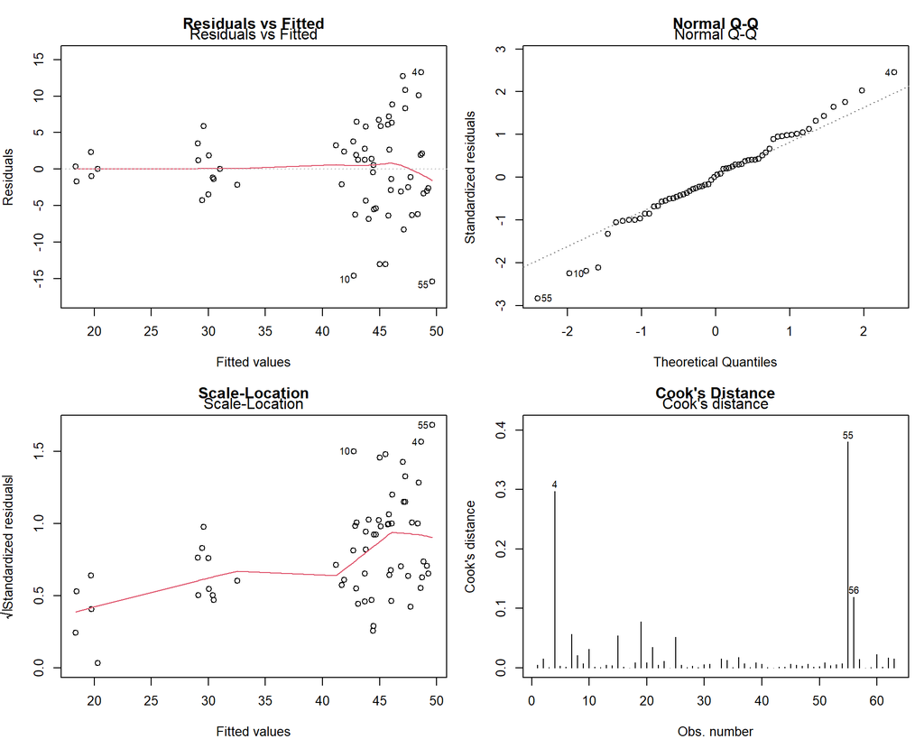

```r
# Fit univariate model for diagnostic plots
cerebro_lm <- lm(
  Cerebrovascular.Mortality ~
    `Adults eating 5 or more fruits or vegetables per day` +
    `Adults who did not participate in leisure time physical activity in last 30 days` +
    factor(`Region Name`),
  data = ny_data
)

par(mfrow = c(2, 2), mar = c(4, 4, 3, 1))
plot(cerebro_lm, which = 1, main = "Residuals vs Fitted")
plot(cerebro_lm, which = 2, main = "Normal Q-Q")
plot(cerebro_lm, which = 3, main = "Scale-Location")
plot(cerebro_lm, which = 4, main = "Cook's Distance")
```

```r
par(mfrow = c(1, 1))
```

> **Diagnostic notes:** The Q-Q plot assesses normality of residuals (points should follow the diagonal). The Residuals vs. Fitted plot checks for non-linearity or heteroscedasticity (points should be randomly scattered). Cook’s Distance identifies influential observations that may disproportionately affect the model.

## 7.4 Effect Size (R²)

```r
data.frame(
  Outcome         = c("Cardiovascular Mortality", "Cerebrovascular Mortality"),
  R_Squared       = c(0.3296, 0.6708),
  Adj_R_Squared   = c(0.2006, 0.6074),
  F_p_value       = c("0.01361", "1.704e-09"),
  Interpretation  = c(
    "Moderate fit — region, diet, and exercise explain 33% of variance",
    "Strong fit — region, diet, and exercise explain 67% of variance"
  )
)
```

| Outcome | R_Squared | Adj_R_Squared | F_p_value | Interpretation |
| --- | --- | --- | --- | --- |
| Cardiovascular Mortality | 0.3296 | 0.2006 | 0.01361 | Moderate fit — region, diet, and exercise explain 33% of variance |
| Cerebrovascular Mortality | 0.6708 | 0.6074 | 1.704e-09 | Strong fit — region, diet, and exercise explain 67% of variance |

# 8 Limitations

# 9 References

Bedre, R. (2021, October 1). *MANOVA using R (with examples and code)*. Data science blog. https://www.reneshbedre.com/blog/manova.html

Centers for Disease Control and Prevention. (2022, October 14). *Stroke facts*. https://www.cdc.gov/stroke/facts.htm

Health.data.ny.gov. (2021, February 25). *Community health obesity and diabetes related indicators: 2008–2012*. HealthData.gov. https://healthdata.gov/State/Community-Health-Obesity-and-Diabetes-Related-Indi/95h9-42q2

Kelli, H. M., et al. (2018). Socioeconomic status and cardiovascular outcomes. *Circulation*. https://www.ahajournals.org/doi/10.1161/CIRCULATIONAHA.117.029652

Navarro, D. (2019). *Learning statistics with R: A tutorial for psychology students and other beginners* (version 0.6.1). Chapter 16: Factorial ANOVA. https://learningstatisticswithr.com/book/anova2.html#factorialanovasimple

Zach. (2022, February 23). *How to plot multiple linear regression results in R*. Statology. https://www.statology.org/plot-multiple-linear-regression-in-r/